# Workshop 2 Fiancial Econometrics

Juan David Torres

Feb 17 2021

# Analyzing Histograms of returns

Clear the environment

```r
rm(list=ls())
# To avoid scientific notation for numbers:
options(scipen=999)
# Load the library
library(quantmod)
```

# Data Collection

Gather the MXX Mexican IPC and GSPC S&P500

```r
# Downloading the historical quotation data for both indexes:
getSymbols(c("^MXX", "^GSPC"), from="2000-01-01",  src="yahoo", periodicity="monthly")
```

[output not shown]

```
## [1] "^MXX"  "^GSPC"
```

# Return calculation

Integrate both indexes

```r
prices = merge(MXX,GSPC)
```

```r
prices = Ad(prices)
names(prices) = c("MXX","GSPC")
```

Calculate CC Returns

```r
r = diff(log(prices))
```

Visualize the CCR

```r
head(r)
```

```
##                    MXX        GSPC
## 2000-01-01          NA          NA
## 2000-02-01  0.11232485 -0.02031300
## 2000-03-01  0.01410906  0.09232375
## 2000-04-01 -0.11811558 -0.03127991
## 2000-05-01 -0.10795263 -0.02215875
## 2000-06-01  0.15323959  0.02365163
```

Omit NA

```r
r = na.omit(r)
```

Calculate simple returns

```r
R =  na.omit(prices / lag(prices,n=1) - 1)
```

Visualize R Head and Tail

```r
head(R)
```

```
##                    MXX        GSPC
## 2000-02-01  0.11887627 -0.02010808
## 2000-03-01  0.01420906  0.09671983
## 2000-04-01 -0.11140666 -0.03079576
## 2000-05-01 -0.10232989 -0.02191505
## 2000-06-01  0.16560422  0.02393355
## 2000-07-01 -0.06247834 -0.01634128
```

```r
tail(R)
```

```
##                    MXX        GSPC
## 2020-09-01  0.01677385 -0.03922797
## 2020-10-01 -0.01256937 -0.02766579
## 2020-11-01  0.12952931  0.10754564
## 2020-12-01  0.05476471  0.03712146
## 2021-01-01 -0.02453426 -0.01113666
## 2021-02-01  0.04453449  0.05939037
```

Omit the NA

```r
R <- na.omit(R)
```

# Histograms

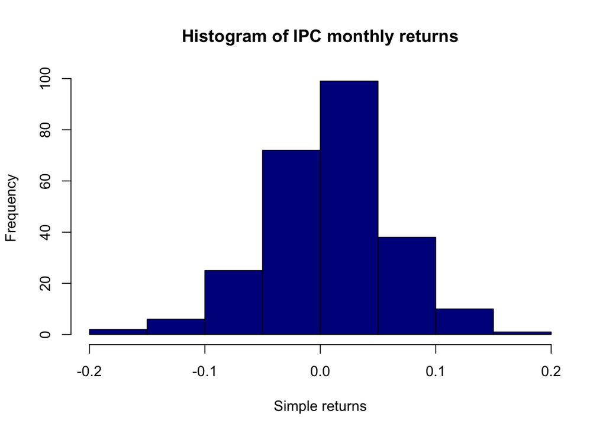

```r
hist(R$MXX, main="Histogram of IPC monthly returns", xlab="Simple returns", col="dark blue")
```

# Q Q: INTERPRET this histogram with your words.  
A: THE FOLLOWING HISTOGRAM HAS MORE FREQUENCY ON BETWEEN 0.0 - 0.05 WHICH MEANS THAT THERE HAVE BEEN POSITIVE MONTHS THAN NEGATIVE. WE CAN ALSO TELL THAT MOST OF THE DATA ARE CONCENTRATED FROM -0.1 AND 0.1. IT CAN BE SEEN THAT THERE HAVE BEEN MORE POSITIVE VALUES OR R SINCE 2000 OF THE IPyC.

Histogram for GSPC

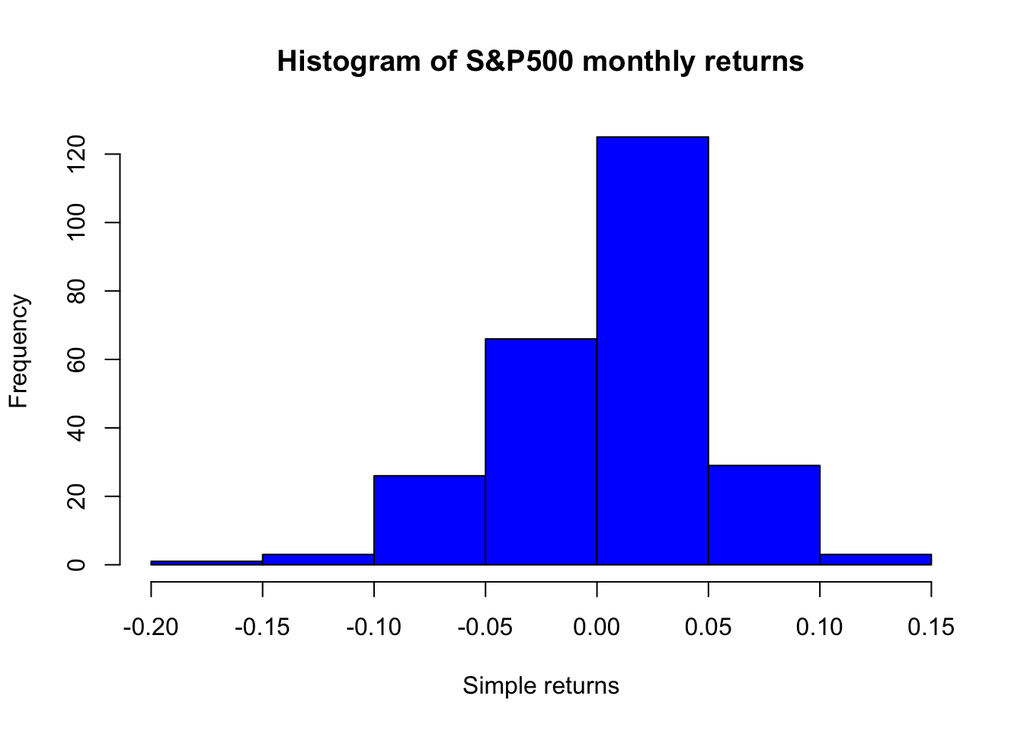

```r
hist(R$GSPC, main="Histogram of S&P500 monthly returns",
     xlab="Simple returns", col="blue")
```

# Q Q: INTERPRET this histogram with your words.  
A: WE CAN SAY THAT THE R WAS MOSTLY CONCENTRATED BETWEEN -0.1 TO -0.1. THERE HAVE BEEN MORE POSITIVE RETURNS THAN NEGATIVE GIVEN THAT 0 TO 0.05 FREQUENCY IS MORE THAN THE NEGATIVE RANGES.

# Q

# Calculation of the mean and the standard deviation

```r
R_Mean_MXX <- mean(R$MXX , na.rm = TRUE)
R_Mean_GSPC <- mean(R$GSPC, na.rm = TRUE)
R_Mean_MXX
```

```
## [1] 0.008993708
```

```r
R_Mean_GSPC
```

```
## [1] 0.005073141
```

```r
R_SD_MXX <- sd(R$MXX, na.rm=TRUE)
R_SD_GSPC <- sd(R$GSPC, na.rm=TRUE)
R_SD_MXX
```

```
## [1] 0.05242227
```

```r
R_SD_GSPC
```

```
## [1] 0.04371317
```

# Q

# Calculating the holding period (Optional)

```r
exp(sum(r$MXX)) - 1
```

```
## [1] 5.817845
```

```r
exp(sum(r$GSPC)) - 1
```

```
## [1] 1.821759
```

# Q

# Q

# The Central Limit Theorem

# Monte Carlo Simulation to create variables

Create x random variable with normal distribution mean = 20 and standard deviation = 40 and 100,000 observations

```r
x <- rnorm(n=100000 , mean = 20, 40)
```

Create y variable with uniform distribution in the range of 0 - 60

```r
y <-  runif(n=100000 , min =0 , max = 60)

(60-0)^2/12
```

```
## [1] 300
```

# Q

Q: HOW CAN YOU ESTIMATE THE VARIANCE OF A UNIFORM DISTRIBUTED VARIABLE?  
A: I RESEARCHED ON INTERNET AND IT SHOWED THAT A WAY TO ESTIMATE THE VALUE OF A UNIFORM DISTRIBUTED VARIABLE IS THROUGH THE FOLLOWING FORMULA ((B-A)^2)/12

# Histogram of x and y

Make a histogram for y and for x

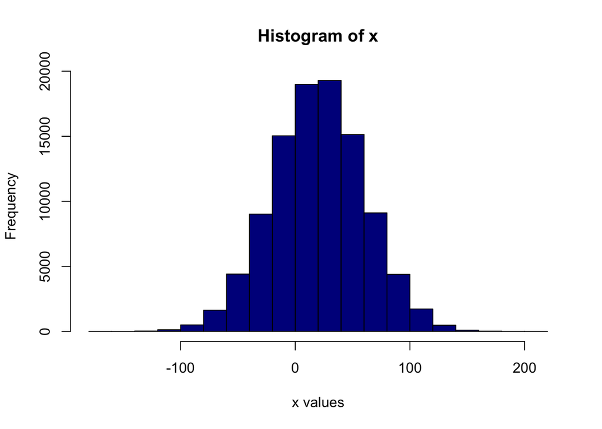

```r
hist(x, main="Histogram of x", xlab="x values", col="dark blue")
```

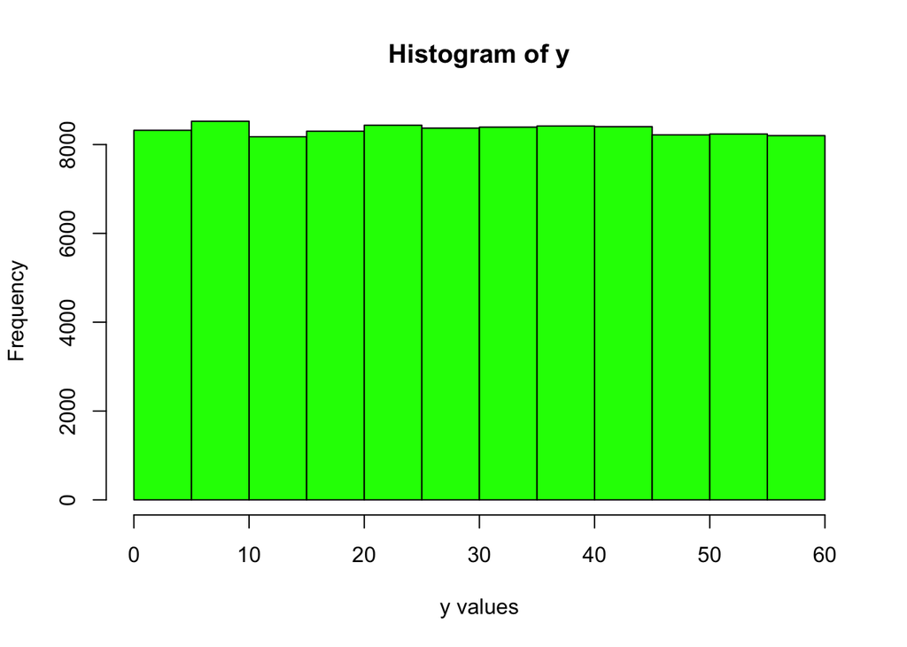

```r
hist(y, main="Histogram of y", xlab="y values", col="green")
```

# Q Q: WHAT DO YOU SEE? BRIEFLY EXPLAIN  
A: IN THE VARIABLE X HISTOGRAM IT CAN BE SEEN IT FOLLOWS A NORMAL DISTRIBUTION WHERE MOST OF THE VALUES ARE CONCENTRATED ON A CERTAIN AREA. ON THE OTHER HAND THE VARIABLE Y HISTOGRAM VALUES ARE ALL UNIFORMALLY DISTRIBUTED FROM 0 TO 60.

# Calculating standard deviation and variance

Calculating the mean for x and y

```r
xbar= mean(x)
ybar= mean(y)
```

Calculation of variance

```r
xdesv2=(x-xbar)^2
ydesv2=(y-ybar)^2

varx=mean(xdesv2)
varx
```

```
## [1] 1605.668
```

```r
vary=mean(ydesv2)
vary
```

```
## [1] 298.9786
```

# Calculating mean of groups for x and y

Create a data frame with x and y as columns

```r
dataset <- cbind(x,y)
dataset <- as.data.frame(dataset)
```

Create 4000 groups of 25 observations

```r
dataset$group <- rep(seq(1:4000),each=25)
```

Compute a sample mean for each group

```r
library(dplyr)
group_means <- dataset %>%
   group_by(group) %>%
   summarise(x_mean = mean(x),
             y_mean = mean(y))
```

Now we create a histogram with the mean of x

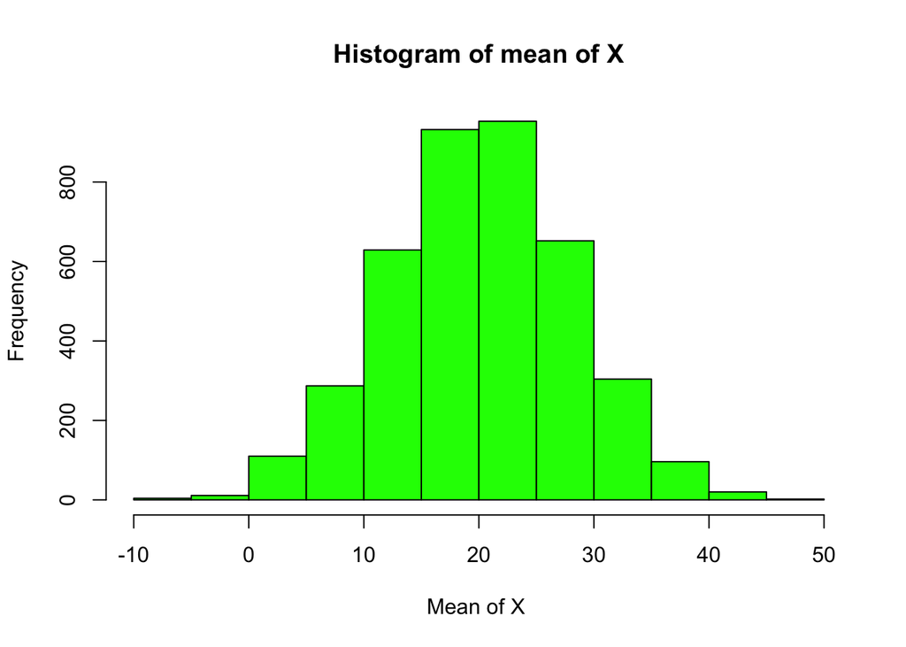

```r
hist(group_means$x_mean, main="Histogram of mean of X", xlab="Mean of X ", col="green")
```

Now a histogram for the means of the uniform distribution

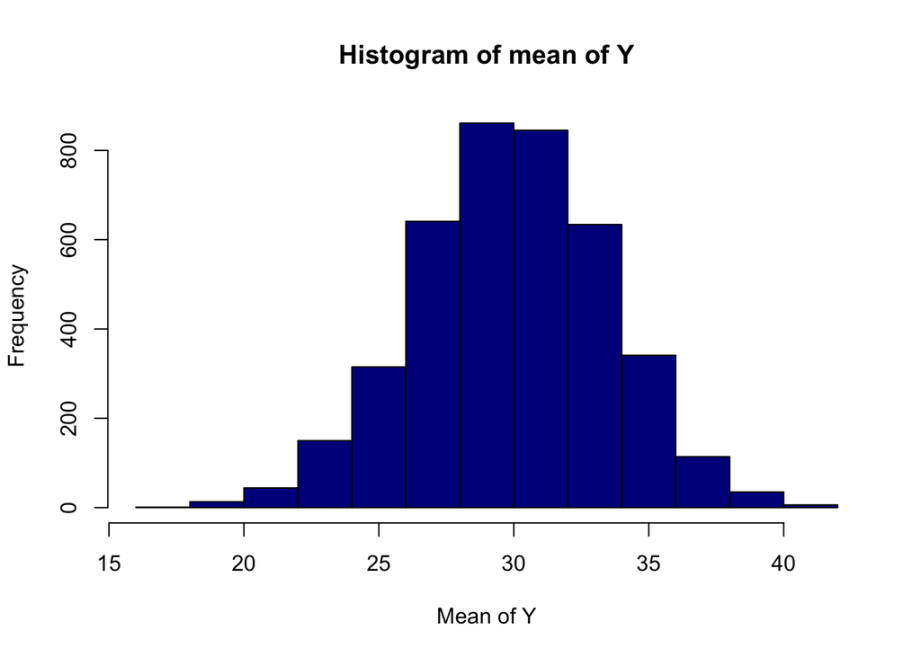

```r
hist(group_means$y_mean, main="Histogram of mean of Y",
     xlab="Mean of Y", col="dark blue")
```

# Q Q: LOOKING AT THE HISTOGRAM OF THE SAMPLE MEAN OF Y (y_mean), HOW DIFFERENT IT IS FROM ITS ORIGINAL HISTOGRAM OF Y (y)?  
A: IT IS VERY DIFFERENT, THE ORIGINAL HISTOGRAM FOLLOWED A UNIFORM DISTRIBUTION WHILE THE HISTOGRAM WITH THE SAMPLE MEANS GROUPED FOLLOWS A NORMAL DISTRIBUTION, THIS IS VERY INTERESTING BECAUSE BY TAKING VALUES FROM A VARIABLE WITH UNIFORM DISTRIBUTION, GROUPING THEM AND TAKING THE MEAN MAKING A HISTOGRAM WITH THOSE MEANS BECOME THE VALUES THEN FOLLOW A NORMAL DISTRIBUTION.

THIS IS BECAUSE THE SAMPLE MEAN HISTOGRAM OF ANY DISTRIBUTION WILL BEHAVE AS A NORMAL DISTRIBUTION, THEORY ALSO KNOWN AS CENTRAL LIMIT THEOREM.

# Q

Q: CALCULATE THE MEAN AND STANDARD DEVIATION OF BOTH SAMPLE MEANS (COLUMNS x_mean AND y_mean). HINT: YOU CAN USE THE mean and sd functions

```r
#A: Calculation of mean
Mean_x_m <- mean(group_means$x_mean, na.rm = TRUE)
Mean_y_m <- mean(group_means$y_mean, na.rm = TRUE)
Mean_x_m
```

```
## [1] 20.11128
```

```r
Mean_y_m
```

```
## [1] 29.91923
```

```r
Mean_x_sd <- sd(group_means$x_mean, na.rm = TRUE)
Mean_y_sd <- sd(group_means$y_mean, na.rm = TRUE)
Mean_x_sd
```

```
## [1] 7.952675
```

```r
Mean_y_sd
```

```
## [1] 3.527716
```

```r
Mean_x_var <- var(group_means$x_mean, na.rm = TRUE)
Mean_y_var <- var(group_means$y_mean, na.rm = TRUE)
Mean_x_var
```

```
## [1] 63.24505
```

```r
Mean_y_var
```

```
## [1] 12.44478
```

# Q

# Q

Q: DO A RESEARCH ABOUT THE CENTRAL LIMIT THEOREM. WITHYOUR WORDS, EXPLAIN WHAT THE CENTRAL THEOREM IS  
A: CENTRAL LIMIT THEOREM IS THE THEOREM THAT STATES THAT NO MATTER THE DISTRIBUTION OF THE VALUES IN A SAMPLE IF YOU TAKE THE SAMPLE MEAN OF THE DIFFERENT SAMPLES THE SAMPLE MEANS WILL FOLLOW A NORMAL DISTRIBUTION. THIS DEPENDS ALSO ON THE SAMPLE SIZE, IF THE SAMPLE SIZE IS BIGGER THE MORE IT ADJUSTS TO A NORMAL DISTRIBUTION.

IT IS SAID THAT FOR THAT TO HAPPEN THE MINIMUM SAMPLE SIZE IS 30 BUT THERE CAN BE SOME EXCEPTIONS WITH LESS SAMPLE SIZE. THERE ARE ALSO SOME DISTRIBUTIONS THAT AREN’T ABLE TO PERFORM A SAMPLE MEAN, WHICH IN THIS CASE THOSE WON’T FOLLOW THE THEOREM BUT FOR THE MAJORITY OF THE DISTRIBUTIONS LIKE UNIFORM OR EXPONENTIAL THE THEOREM DOES WORK.